# Weather and Corn Yield Regressions

## Temperature trends

### Summer temperature trends: Winneshiek County

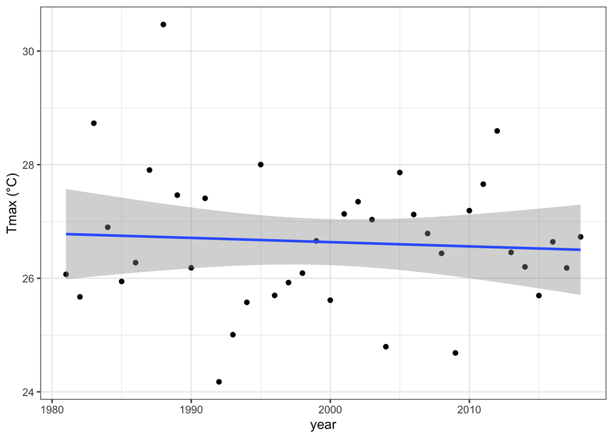

```r
tmaxdf$doy <- as.numeric(tmaxdf$doy)
tmaxdf$year <- as.numeric(as.character(tmaxdf$year))

winnesummer <- tmaxdf %>%
  filter(countyfp==191 & doy >= 152 & doy <= 243) %>%
  group_by(year) %>%
  summarize(meantmax = mean(tmax))

ggplot(winnesummer, mapping = aes(x = year, y = meantmax)) +
  geom_point() +
  theme_bw() +
  labs(x = "year", y = "Tmax (°C)") +
  geom_smooth(method = lm)
```

```r
lm_summertmax <- lm(meantmax ~ year, winnesummer)
summary(lm_summertmax)
```

```
##
## Call:
## lm(formula = meantmax ~ year, data = winnesummer)
##
## Residuals:
##     Min      1Q  Median      3Q     Max
## -2.5189 -0.7867 -0.0341  0.6859  3.7415
##
## Coefficients:
##             Estimate Std. Error t value Pr(>|t|)
## (Intercept) 41.57670   36.44848   1.141    0.262
## year        -0.00747    0.01823  -0.410    0.684
##
## Residual standard error: 1.232 on 36 degrees of freedom
## Multiple R-squared:  0.004644,   Adjusted R-squared:  -0.02301
## F-statistic: 0.168 on 1 and 36 DF,  p-value: 0.6844
```

### Winter Temperatures - Winneshiek County

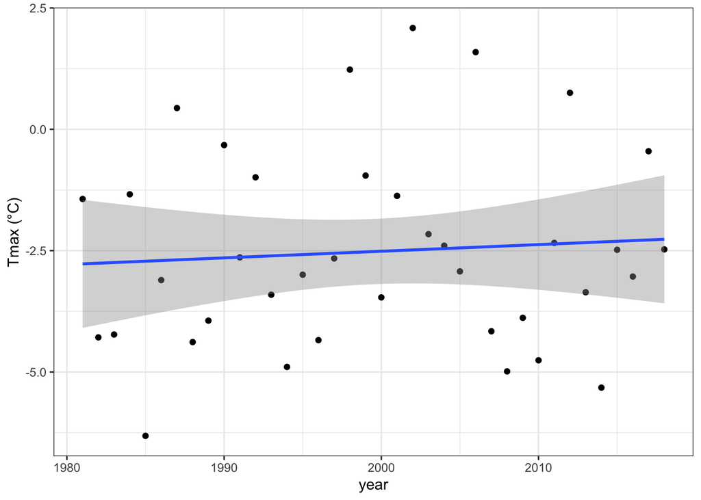

```r
winnewinter <- tmaxdf %>%
  filter(countyfp==191 & (doy <= 59 | doy >= 335) & !is.na(tmax)) %>%
  group_by(year) %>%
  summarize(meantmax = mean(tmax))

ggplot(winnewinter, mapping = aes(x = year, y = meantmax)) +
  geom_point() +
  theme_bw() +
  labs(x = "year", y = "Tmax (°C)") +
  geom_smooth(method = lm)
```

```r
lm_wintertmax <- lm(meantmax ~ year, winnewinter)
summary(lm_wintertmax)
```

```
##
## Call:
## lm(formula = meantmax ~ year, data = winnewinter)
##
## Residuals:
##     Min      1Q  Median      3Q     Max
## -3.5978 -1.4917 -0.3053  1.3778  4.5709
##
## Coefficients:
##              Estimate Std. Error t value Pr(>|t|)
## (Intercept) -29.87825   60.48100  -0.494    0.624
## year          0.01368    0.03025   0.452    0.654
##
## Residual standard error: 2.045 on 36 degrees of freedom
## Multiple R-squared:  0.005652,   Adjusted R-squared:  -0.02197
## F-statistic: 0.2046 on 1 and 36 DF,  p-value: 0.6537
```

### Multiple regression – Quadratic time trend

```r
winnewinter$yearsq <- winnewinter$year^2

lm_wintertmaxquad <- lm(meantmax ~ year + yearsq, winnewinter)
summary(lm_wintertmaxquad)
```

```
##
## Call:
## lm(formula = meantmax ~ year + yearsq, data = winnewinter)
##
## Residuals:
##     Min      1Q  Median      3Q     Max
## -3.3539 -1.2985 -0.2813  1.4055  4.2620
##
## Coefficients:
##               Estimate Std. Error t value Pr(>|t|)
## (Intercept) -1.086e+04  1.238e+04  -0.877    0.386
## year         1.085e+01  1.239e+01   0.876    0.387
## yearsq      -2.710e-03  3.097e-03  -0.875    0.388
##
## Residual standard error: 2.051 on 35 degrees of freedom
## Multiple R-squared:  0.02694,    Adjusted R-squared:  -0.02867
## F-statistic: 0.4845 on 2 and 35 DF,  p-value: 0.6201
```

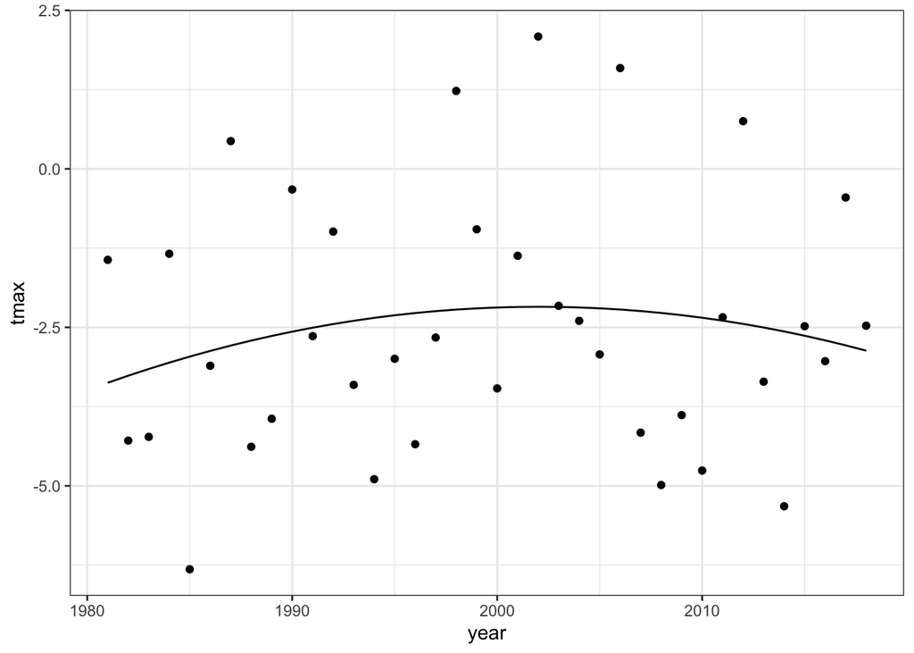

```r
winnewinter$fitted <- lm_wintertmaxquad$fitted.values

ggplot(winnewinter) +
  geom_point(mapping = aes(x = year, y = meantmax)) +
  geom_line(mapping = aes(x = year, y = fitted)) +
  theme_bw() +
  labs(x = "year", y = "tmax")
```

### Download NASS corn yield data

## Assignment

### Question 1a: Extract Winneshiek County corn yields, fit a linear time trend, make a plot. Is there a significant time trend?

```r
# Filter for Winneshiek County
winnecorn <- cornyields %>%
  filter(county_name == 'WINNESHIEK')

# Fit a linear time trend
lm_winnecorn <- lm(yield ~ year, winnecorn)
summary(lm_winnecorn)
```

```
##
## Call:
## lm(formula = yield ~ year, data = winnecorn)
##
## Residuals:
##     Min      1Q  Median      3Q     Max
## -51.163  -1.841   2.363   9.437  24.376
##
## Coefficients:
##              Estimate Std. Error t value Pr(>|t|)
## (Intercept) -4763.290    448.286  -10.63 4.46e-13 ***
## year            2.457      0.224   10.96 1.77e-13 ***
## ---
## Signif. codes:  0 '***' 0.001 '**' 0.01 '*' 0.05 '.' 0.1 ' ' 1
##
## Residual standard error: 16.97 on 39 degrees of freedom
## Multiple R-squared:  0.7551, Adjusted R-squared:  0.7488
## F-statistic: 120.2 on 1 and 39 DF,  p-value: 1.767e-13
```

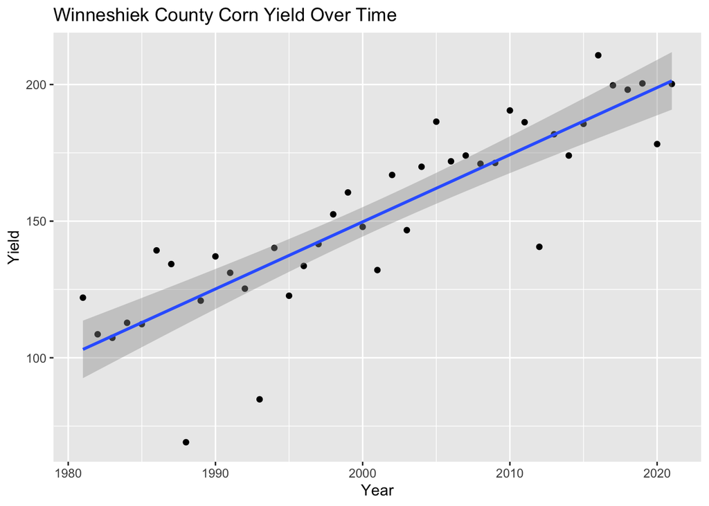

```r
# Make a Plot
ggplot(winnecorn) + aes(x=year, y= yield) + geom_point() + geom_smooth(method = lm) + xlab('Year') + ylab('Yield') + ggtitle('Winneshiek County Corn Yield Over Time')
```

Yes, over time yield is increasing.

### Question 1b: Fit a quadratic time trend (i.e., year + year^2) and make a plot. Is there evidence for slowing yield growth?

```r
# Create Year Squared Column
winnecorn$yearsq <- winnecorn$year^2

#LM Fit
lm_winnecornquad <- lm(yield ~ year + yearsq, winnecorn)
summary(lm_winnecornquad)
```

```
##
## Call:
## lm(formula = yield ~ year + yearsq, data = winnecorn)
##
## Residuals:
##     Min      1Q  Median      3Q     Max
## -51.384  -3.115   1.388   9.743  25.324
##
## Coefficients:
##               Estimate Std. Error t value Pr(>|t|)
## (Intercept)  2.583e+04  8.580e+04   0.301    0.765
## year        -2.812e+01  8.576e+01  -0.328    0.745
## yearsq       7.641e-03  2.143e-02   0.357    0.723
##
## Residual standard error: 17.17 on 38 degrees of freedom
## Multiple R-squared:  0.7559, Adjusted R-squared:  0.7431
## F-statistic: 58.84 on 2 and 38 DF,  p-value: 2.311e-12
```

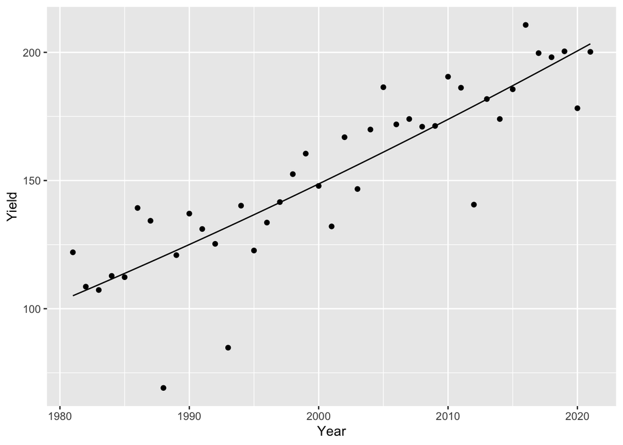

```r
winnecorn$fitted <- lm_winnecornquad$fitted.values

# Make a Plot
ggplot(winnecorn) +
  geom_point(mapping = aes(x = year, y = yield)) +
  geom_line(mapping = aes(x = year, y = fitted)) + xlab ('Year') + ylab('Yield')
```

There is not evidence to suggest slowing yield growth.

### Question 2 – Time Series: Let’s analyze the relationship between temperature and yields for the Winneshiek County time series. Use data on yield and summer avg Tmax. Is adding year or Tmax^2 to your model helpful? Make a plot and interpret the results.

```r
# Combine Yield and Temp Data Sets
winnecombo <- inner_join(winnecorn, winnesummer, by = 'year')

# Create TMaxSq Column in Combo Data Set
winnecombo$Tmaxsq <- winnecombo$meantmax^2

# Lm for yield and temp
lm_TempYield <- lm(yield ~ year + meantmax + Tmaxsq, winnecombo)
summary(lm_TempYield)
```

```
##
## Call:
## lm(formula = yield ~ year + meantmax + Tmaxsq, data = winnecombo)
##
## Residuals:
##     Min      1Q  Median      3Q     Max
## -44.683  -5.427   1.214   8.943  25.127
##
## Coefficients:
##               Estimate Std. Error t value Pr(>|t|)
## (Intercept) -7280.2956   755.2808  -9.639 2.96e-11 ***
## year            2.3286     0.2166  10.752 1.77e-12 ***
## meantmax      208.9004    52.9773   3.943 0.000381 ***
## Tmaxsq         -3.9259     0.9799  -4.006 0.000318 ***
## ---
## Signif. codes:  0 '***' 0.001 '**' 0.01 '*' 0.05 '.' 0.1 ' ' 1
##
## Residual standard error: 14.27 on 34 degrees of freedom
## Multiple R-squared:  0.8277, Adjusted R-squared:  0.8125
## F-statistic: 54.43 on 3 and 34 DF,  p-value: 4.538e-13
```

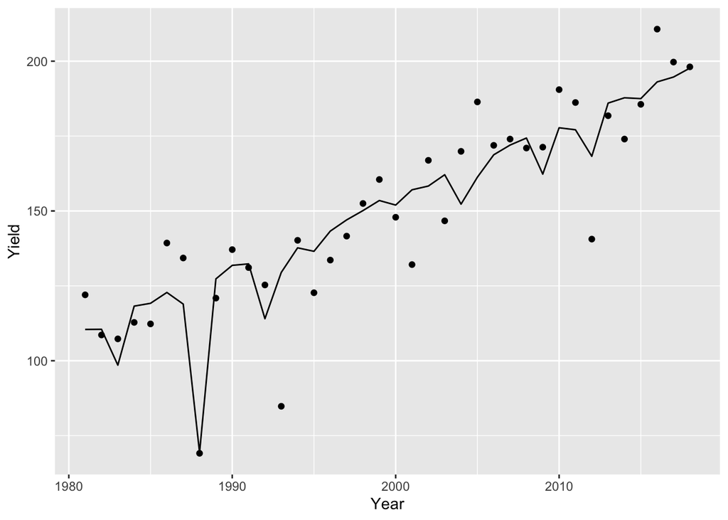

```r
winnecombo$fitted <- lm_TempYield$fitted.values

# Make a plot
ggplot(winnecombo) + geom_point(mapping = aes(x= year, y= yield)) + geom_line(mapping = aes(x = year, y= fitted)) + xlab ('Year') +ylab('Yield')
```

### Question 3 – Cross-Section: Analyze the relationship between temperature and yield across all counties in 2018. Is there a relationship? Interpret the results.

```r
#Filter corn for only 2018
corn2018 <- cornyields %>%
  filter(year == 2018) %>%
  rename(countyfp = "county_ansi")

#Filter tmaxdf for 2018, get means
tmax2018 <- tmaxdf %>%
  filter(year == 2018) %>%
  filter(!is.na(tmax)) %>%
  filter(doy >= 152 & doy <=243) %>%
  group_by(countyfp, year) %>%
  summarize(
    mean = mean(tmax))
```

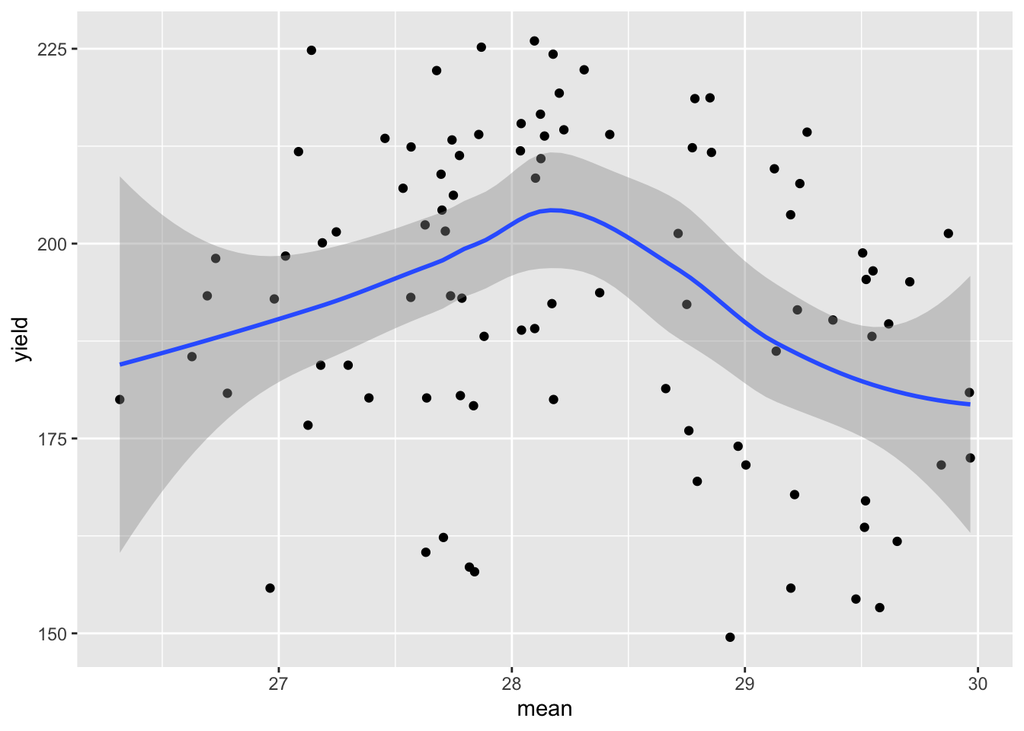

```r
#factor to numeric
tmax2018$countyfp <- as.numeric(as.character(tmax2018$countyfp))

#combine the data sets
countyyields <- left_join(corn2018, tmax2018, by='countyfp')

#plot
ggplot(countyyields) + aes(x= mean, y= yield) + geom_point() +geom_smooth()
```

There is a positive relationship between yield and average temperature to a point (about 28.2 degrees) and then there is a negative relationship. So at first, as temperature increases so does yield, but then when temperature continues to increase yield begins to decrease. This could be because of the ideal temperature range of corn. Once the temperature increases beyond the ideal temperature, yields suffer. But, this could also be caused due to other factors not considered within the model such as types of management practices at different temperatures.

### Question 4 – Panel: One way to leverage multiple time series is to group all data into what is called a “panel” regression. Convert the county ID code (“countyfp” or “county_ansi”) into factor using as.factor, then include this variable in a regression using all counties’ yield and summer temperature data. How does the significance of your temperature coefficients (Tmax, Tmax^2) change? Make a plot comparing actual and fitted yields and interpret the results of your model.

```r
# prep data

summertmaxdf <- tmaxdf %>%
  filter(doy >= 152 & doy <= 243) %>%
  group_by(countyfp, year) %>%
  summarize(meantmax = mean(tmax)) %>%
  rename(county_ansi = countyfp)
cornyields$county_ansi <- as.factor(cornyields$county_ansi)

summeryieldtemps <- left_join(summertmaxdf, cornyields, by=c('county_ansi', 'year')) %>%
  filter(!is.na(yield))

# add tmaxsq column

summeryieldtemps$tmaxsq <- summeryieldtemps$meantmax^2

# lm for county, yield, and temp

lm_CountyTempYield <- lm(yield ~ meantmax + tmaxsq + year + county_ansi, summeryieldtemps)
summary(lm_CountyTempYield)
```

```
##
## Call:
## lm(formula = yield ~ meantmax + tmaxsq + year + county_ansi,
##     data = summeryieldtemps)
##
## Residuals:
##     Min      1Q  Median      3Q     Max
## -81.645  -9.720   1.924  13.232  40.409
##
## Coefficients:
##                  Estimate Std. Error t value Pr(>|t|)
## (Intercept)    -5.815e+03  9.802e+01 -59.319  < 2e-16 ***
## meantmax        1.182e+02  6.108e+00  19.352  < 2e-16 ***
## tmaxsq         -2.225e+00  1.085e-01 -20.503  < 2e-16 ***
## year            2.203e+00  2.836e-02  77.664  < 2e-16 ***
## county_ansi147 -4.601e+00  4.322e+00  -1.065 0.287100
## county_ansi13  -4.573e+00  4.322e+00  -1.058 0.290041
## county_ansi99   2.537e+00  4.322e+00   0.587 0.557264
## county_ansi195 -5.740e+00  4.339e+00  -1.323 0.186000
## county_ansi67  -7.072e+00  4.324e+00  -1.636 0.102029
## county_ansi107 -9.660e+00  4.325e+00  -2.233 0.025596 *
## county_ansi15   3.120e+00  4.322e+00   0.722 0.470379
## county_ansi57  -1.366e+00  4.327e+00  -0.316 0.752212
## county_ansi127  2.318e+00  4.321e+00   0.536 0.591719
## county_ansi123 -3.711e+00  4.325e+00  -0.858 0.390951
## county_ansi81  -3.157e+00  4.327e+00  -0.729 0.465744
## county_ansi129 -1.637e+00  4.396e+00  -0.372 0.709703
## county_ansi1   -1.186e+01  4.325e+00  -2.743 0.006124 **
## county_ansi175 -2.341e+01  4.354e+00  -5.377 8.03e-08 ***
## county_ansi19  -4.212e+00  4.324e+00  -0.974 0.330092
## county_ansi37  -9.693e+00  4.328e+00  -2.240 0.025182 *
## county_ansi109  3.589e-01  4.324e+00   0.083 0.933863
## county_ansi165 -4.189e+00  4.322e+00  -0.969 0.332408
## county_ansi51  -2.644e+01  4.360e+00  -6.063 1.47e-09 ***
## county_ansi69  -5.518e-01  4.322e+00  -0.128 0.898414
## county_ansi137 -5.977e+00  4.330e+00  -1.381 0.167514
## county_ansi9   -6.795e+00  4.322e+00  -1.572 0.115958
## county_ansi87  -6.583e+00  4.328e+00  -1.521 0.128366
## county_ansi5   -9.147e+00  4.329e+00  -2.113 0.034697 *
## county_ansi189 -3.627e+00  4.330e+00  -0.838 0.402306
```

[output cut: 64 more lines]

```
## county_ansi183 -1.446e+00  4.328e+00  -0.334 0.738278
## county_ansi33  -7.281e+00  4.326e+00  -1.683 0.092484 .
## county_ansi43  -2.998e+00  4.326e+00  -0.693 0.488271
## county_ansi73   2.754e+00  4.323e+00   0.637 0.524176
## county_ansi161 -2.473e+00  4.321e+00  -0.572 0.567164
## county_ansi103 -7.483e+00  4.322e+00  -1.731 0.083476 .
## county_ansi119 -2.534e+00  4.321e+00  -0.586 0.557604
## county_ansi163  4.415e+00  4.321e+00   1.022 0.306959
## county_ansi171 -2.122e+00  4.321e+00  -0.491 0.623334
## ---
## Signif. codes:  0 '***' 0.001 '**' 0.01 '*' 0.05 '.' 0.1 ' ' 1
##
## Residual standard error: 18.83 on 3646 degrees of freedom
## Multiple R-squared:  0.7207, Adjusted R-squared:  0.7129
## F-statistic: 93.13 on 101 and 3646 DF,  p-value: < 2.2e-16
```

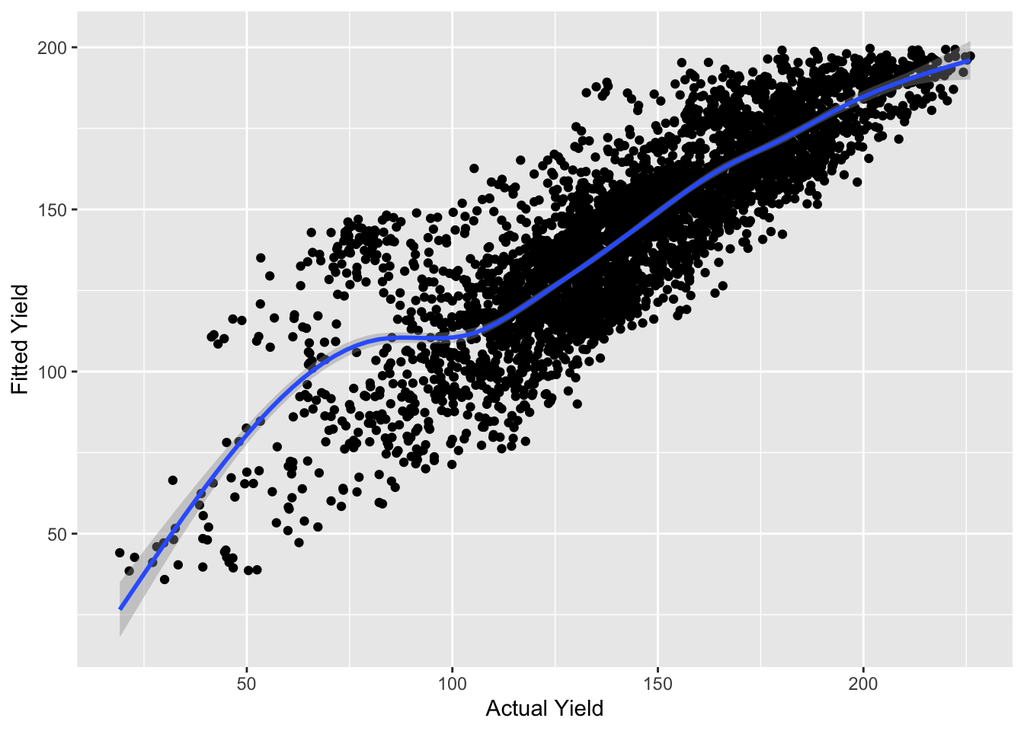

```r
summeryieldtemps$fitted <- lm_CountyTempYield$fitted.values

# Make a plot
ggplot(summeryieldtemps, aes(x= yield, y= fitted)) + geom_point() + geom_smooth() + xlab ('Actual Yield') +ylab('Fitted Yield')
```

### Question 5 – Soybeans: Download NASS data on soybean yields and explore either a time series relationship for a given county, the cross-sectional relationship for a given year, or a panel across all counties and years.

```r
# Create dataset for winnesheik county for soybeans
winnesoy <- soybeansyields %>%
  filter(county_name == 'WINNESHIEK')

# Combine Yield and Temp Data Sets
winnesoycombo <- inner_join(winnesoy, winnesummer, by = 'year')

# Create TMaxSq Column in Combo Data Set
winnesoycombo$Tmaxsq <- winnesoycombo$meantmax^2

# Lm for yield and temp
lm_SoyTempYield <- lm(yield ~ year + meantmax + Tmaxsq, winnesoycombo)
summary(lm_SoyTempYield)
```

```
##
## Call:
## lm(formula = yield ~ year + meantmax + Tmaxsq, data = winnesoycombo)
##
## Residuals:
##      Min       1Q   Median       3Q      Max
## -15.3872  -2.8753   0.7528   3.3727   8.2051
##
## Coefficients:
##               Estimate Std. Error t value Pr(>|t|)
## (Intercept) -1.722e+03  2.826e+02  -6.094 6.51e-07 ***
## year         5.271e-01  8.104e-02   6.504 1.92e-07 ***
## meantmax     5.296e+01  1.982e+01   2.672   0.0115 *
## Tmaxsq      -9.826e-01  3.667e-01  -2.680   0.0113 *
## ---
## Signif. codes:  0 '***' 0.001 '**' 0.01 '*' 0.05 '.' 0.1 ' ' 1
##
## Residual standard error: 5.34 on 34 degrees of freedom
## Multiple R-squared:  0.6386, Adjusted R-squared:  0.6067
## F-statistic: 20.02 on 3 and 34 DF,  p-value: 1.182e-07
```

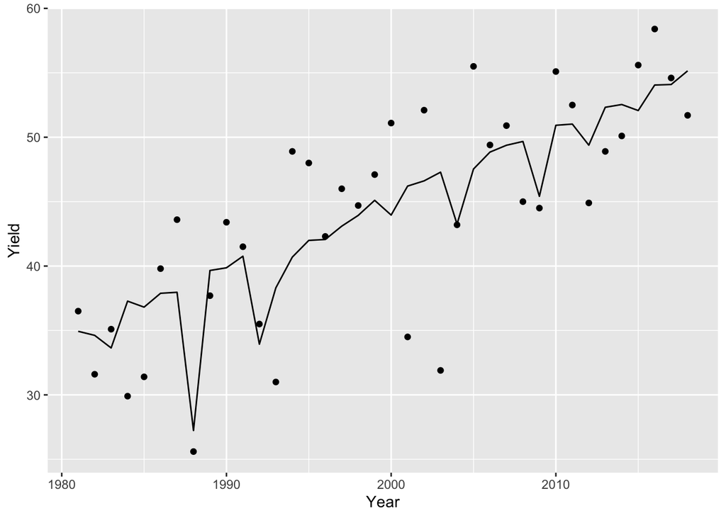

```r
winnesoycombo$fitted <- lm_SoyTempYield$fitted.values

# Make a plot
ggplot(winnesoycombo) + geom_point(mapping = aes(x= year, y= yield)) + geom_line(mapping = aes(x = year, y= fitted)) + xlab ('Year') +ylab('Yield')
```

### Bonus: Find a package to make a county map of Iowa displaying some sort of information about yields or weather. Interpret your map.

```r
states <- us_states()

counties <- us_counties(states = 'Iowa')
countiesfixed <- counties[!duplicated(as.list(counties))]

countycornyields2021 <- cornyields %>%
  rename(countyfp = 'county_ansi')  %>%
  filter(year == '2021')

spatialcornyields2021 <- left_join(countiesfixed, countycornyields2021, by = 'countyfp')

iowa <- states %>%
  filter(name == 'Iowa') %>%
  st_transform(2163)

mapview(spatialcornyields2021, zcol = "yield")
```

[interactive chart not shown]

This map shows that not every county in Iowa produced corn in 2021 (or didn’t report the corn yield). The county that produced the most corn was Sac County. There is no clear spatial pattern relating to where corn is or is not produced. Overall corn is produced throughout the entire state of Iowa.

### Bonus #2: Challenge question - map trends in corn yields by county across Iowa. Interpret your map.

```r
countycornyields <- cornyields %>%
  rename(countyfp = 'county_ansi')
spatialcornyields <- left_join(countiesfixed, countycornyields, by = 'countyfp')

years <- c(1981:2021)

cornmapper <- function(df, year){
  map <- mapview(df, zcol = 'yield', at = c(0, 25, 50, 75, 100, 125, 150, 175, 200, 225, 250))
  print(map)
}

for (year in years){
  cornmapper(spatialcornyields, year)
}
```

I was able to create a function that creates a map of Iowa and corn yields every year of data, however I wasn’t able to turn it into a single map that shows the change over time. It appears that corn yields don’t change drastically overtime, which means either my function is broken or the years aren’t actually changing. I believe the counties that produce should change slightly and yields should change over time.